# Weather

```r
library(GSODR) #run: install.packages("GSODR")
library(mosaic)
library(car)
library(DT)
library(pander)
# to get the GSODR package. You'll need this package to pull in your weather data.
load(system.file("extdata", "isd_history.rda", package = "GSODR"))
```

```r
#Run: View(rexburg)
#To see what columns mean, go here: https://cran.r-project.org/web/packages/GSODR/vignettes/GSODR.html#appendices

#Then run a similar code to get your station information for your weather stations.
#(If you want to use rexburg, then just use one of the following codes)
KYOTO <- get_GSOD(years = 2023, station = "477590-99999")
OSAKA <- get_GSOD(years = 2023, station = "476620-99999")
Rexburg <- get_GSOD(years = 2023, station = "726818-94194")

#Finally, join your two datasets together into one dataset:
weather <- rbind(KYOTO, Rexburg)
```

## Background

For this week’s assignment, I decided to compare the temperature correlations between the Japanese city of KYOTO and Rexburg. Using the “month” variable to achieve the goal of finding which city is hotter for tourists with preferences towards hotter regions.

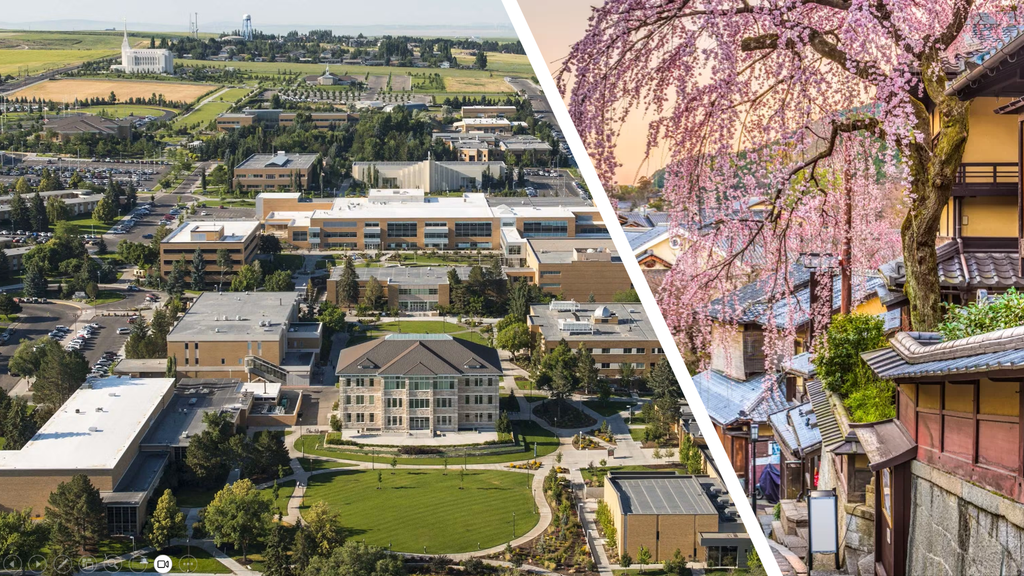

## The Data

To make the comparison fair, both cities’ data come from the same source, the US National Centers for Environmental Information (NCEI)“, to ensure consistent equipment is used in collecting the data.